# Parcial fundamentos

Nombres: DYLAN GABRIEL GONZALEZ SANCHEZ y GERARDO ROCHA BENIGNO

**Entrega:** 16 de octubre antes de las 16:00 horas por Canvas.

**Instrucciones:**

- Tus respuestas deben ser claras y debes explicar los resultados, incluye también tus procedimientos/código de manera ordenada, y el código comentado.
- Se evaluará la presentación de resultados (calidad de las gráficas, tablas, …), revisa la sección de visualización en las notas.
- Se puede realizar individual o en parejas.
- Si tienes preguntas puedes escribirlas en el anuncio de canvas del examen, será el único medio para resolver dudas del examen.

```r
knitr::opts_chunk$set(echo = TRUE, error = TRUE)
library(tidyverse)
library(readr)
library(patchwork)
library(lineup)
library(nullabor)
library(gt)
library(srvyr)
library(ggrepel)
```

## Pruebas de hipótesis

### 1. Pruebas de hipótesis: Ascorbato

Pacientes con cancer terminal avanzado en el estómago y mama se trataron con ascorbato para prolongar la supervivencia. Los datos `ascorbate` muestran la supervivencia en días. Trabaja con los datos en escala logarítimica.

1. Realiza una prueba de hipótesis visual para comparar las mediciones de los dos grupos. Describe tus conclusiones.

Antes de realizar la prueba de hipótesis visual, visualizaremos la distribución de días de supervivencia de la muestra original. A primera vista, pareciera que la distribución del número de días tiende a valores más elevados para los pacientes con cancer de mamá que a los pacientes con cáncer de estómago, aunque la hipotesis visual nos ayudará a corroborar si esto es cierto o no.

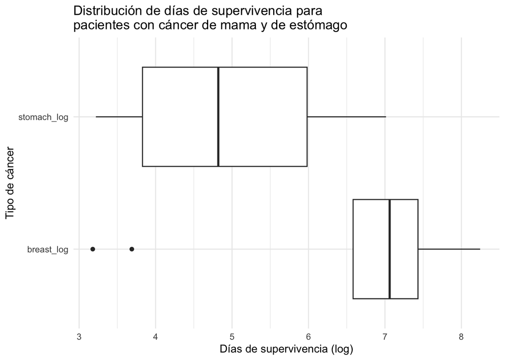

```r
#graficar la distribucion original y conmparara ambos tipos
ascorbate <- read_csv("datos/ascorbate.csv", show_col_types = FALSE)
ascorbate_log_long <- ascorbate %>%
  mutate(
    stomach_log = log(stomach),
    breast_log = log(breast)
  ) %>%
  select(stomach_log, breast_log) %>%
  pivot_longer(cols = everything(), names_to = "type", values_to = "survival") %>%
  na.omit()

ggplot(ascorbate_log_long, aes(x = type, y = survival)) +
  coord_flip() +
  geom_boxplot() +
  theme_minimal() +
  labs(title = "Distribución de días de supervivencia para\npacientes con cáncer de mama y de estómago",
       x = "Tipo de cáncer",
       y = "Días de supervivencia (log)")
```

Ahora realizamos las permutaciones

```r
set.seed(123)
perms_type <- lineup(null_permute("type"), ascorbate_log_long, n = 20)
```

```
## decrypt("o0vr 8ZGZ D3 k5fDGD53 Y1")
```

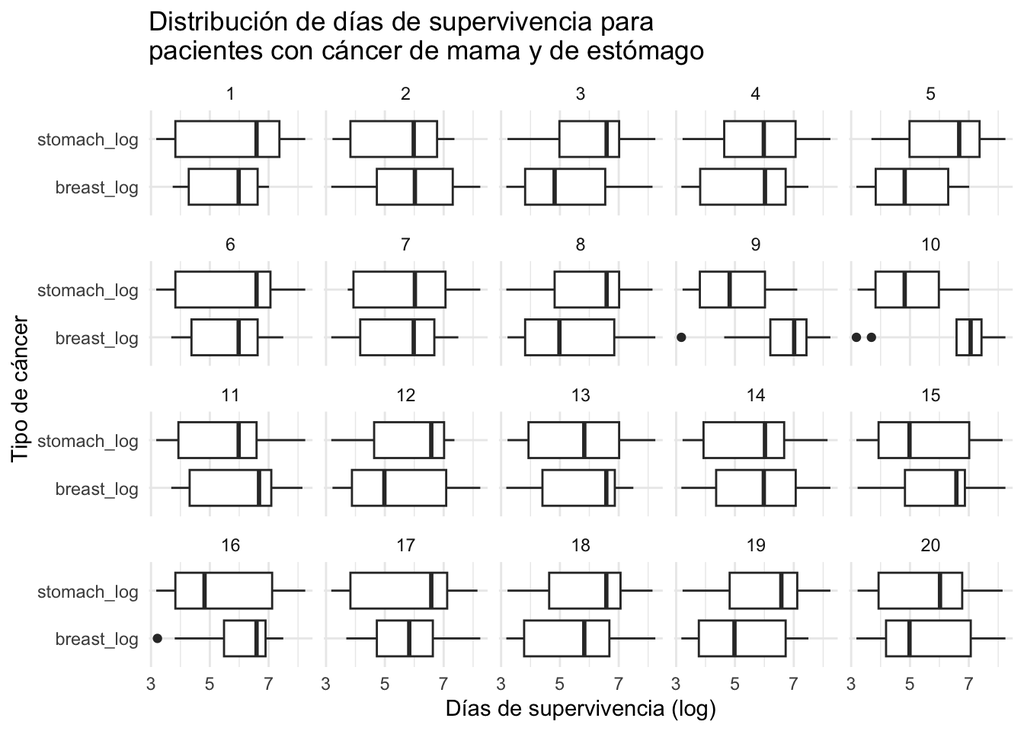

```r
ggplot(perms_type, aes(x = type, y = survival)) +
  coord_flip() +
  geom_boxplot() +
  facet_wrap(~ .sample, ncol=5) +
  scale_y_continuous(breaks = c(3, 5, 7))  +
  theme_minimal() +
  labs(title = "Distribución de días de supervivencia para\npacientes con cáncer de mama y de estómago",
       x = "Tipo de cáncer",
       y = "Días de supervivencia (log)")
```

Es evidente qué la gráfica de caja y brazos que pertenece a la muestra original es la gráfica 10, entonces podemos decir que rechazamos la hipotesis nula de que ambas distribuciones (cancer de mama y de estomago) provienen de la misma distribucion.

2. Usa una prueba de permutación para examinar la hipótesis de que no hay diferencia en la media de los tiempos de supervivencia. Escribe la hipóteisis nula, hipótesis alterna, y reporta el valor $p$ de la prueba.

Hipotesis nula: No hay diferencia en la media de los tiempos de supervivencia Hipotesis alterna: Hay una diferencia en la media de los tiempos de supervivencia entre los grupos de cancer de mama y cancer de estomago.

Primero revisamos nuestra tabla de permutaciones

```r
dif_obs <- ascorbate_log_long %>%
  group_by(type) %>%
  summarise(prom=mean(survival), .groups = 'drop' ) %>%
  pivot_wider(names_from = type, values_from = prom) %>%
  mutate(diferencia_prom = breast_log - stomach_log) %>%
  pull(diferencia_prom) %>%
  round(3)

perms_survival <- lineup(null_permute("survival"),
                        ascorbate_log_long, n = 5000)
```

```
## decrypt("o0vr 8ZGZ D3 k5fDGD53 eee")
```

```r
glimpse(perms_survival)
```

```
## Rows: 120,000
## Columns: 3
## $ type     <chr> "stomach_log", "breast_log", "stomach_log", "breast_log", "st…
## $ survival <dbl> 3.806662, 5.828946, 6.577861, 6.588926, 8.149024, 8.244859, 4…
## $ .sample  <dbl> 1, 1, 1, 1, 1, 1, 1, 1, 1, 1, 1, 1, 1, 1, 1, 1, 1, 1, 1, 1, 1…
```

Despues mostramos nuestros valores de referencia

```r
valores_ref <- perms_survival %>%
  group_by(.sample, type) %>%
  summarise(prom=mean(survival), .groups = 'drop') %>%
  pivot_wider(names_from = type, values_from = prom) %>%
  mutate(diferencia = breast_log - stomach_log)

glimpse(valores_ref)
```

```
## Rows: 5,000
## Columns: 4
## $ .sample     <dbl> 1, 2, 3, 4, 5, 6, 7, 8, 9, 10, 11, 12, 13, 14, 15, 16, 17,…
## $ breast_log  <dbl> 5.838482, 5.043259, 6.364064, 5.994241, 5.812663, 6.054783…
## $ stomach_log <dbl> 5.577253, 6.250134, 5.132530, 5.445457, 5.599100, 5.394229…
## $ diferencia  <dbl> 0.26122950, -1.20687575, 1.23153475, 0.54878350, 0.2135635…
```

Graficamos la distribucion de nuestros valores de referencia

```r
# Función de distribución acumulada (inverso de función de cuantiles)
dist_perm <- ecdf(valores_ref$diferencia)
# Calculamos el percentil del valor observado
percentil_obs <- dist_perm(dif_obs)
percentil_obs
```

```
## [1] 0.9916
```

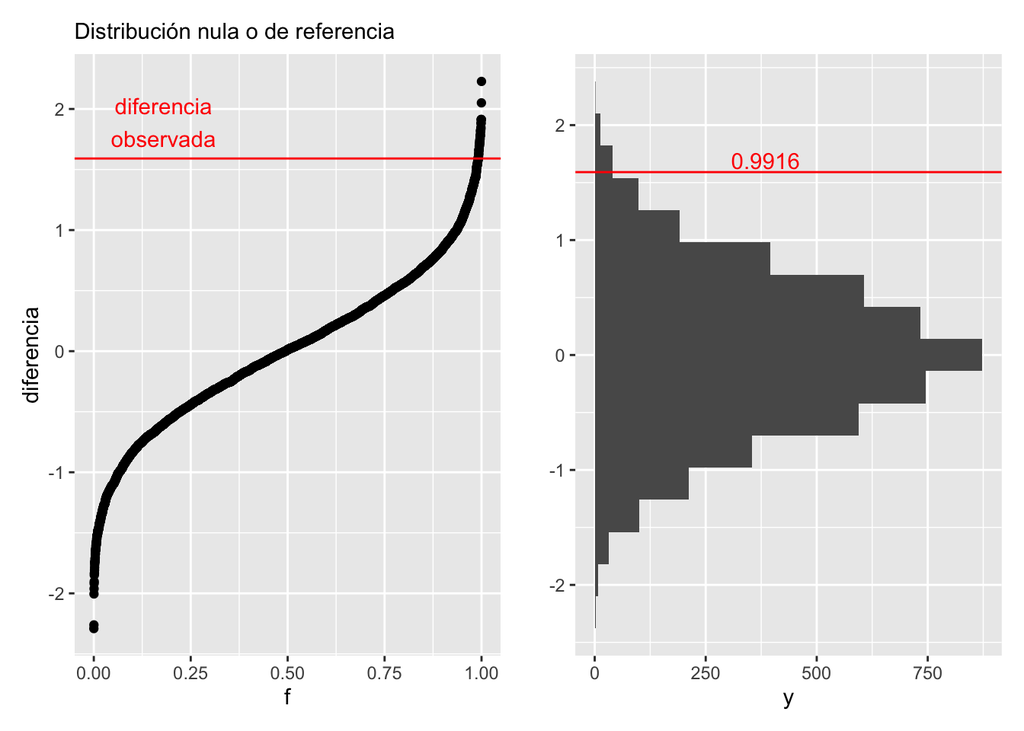

```r
g_1 <- ggplot(valores_ref, aes(sample = diferencia)) + geom_qq(distribution = stats::qunif)  +
  xlab("f") + ylab("diferencia") + labs(subtitle = "Distribución nula o de referencia") +
  geom_hline(yintercept = dif_obs, colour = "red") +
  annotate("text", x = 0.18, y = dif_obs + 0.30, label = "diferencia\nobservada", colour = "red")
g_2 <- ggplot(valores_ref, aes(x = diferencia)) + geom_histogram(binwidth = 0.28) +
  coord_flip() + xlab("") + labs(subtitle = " ") +
  geom_vline(xintercept = dif_obs, colour = "red") +
  annotate("text", x = dif_obs, y = 385, label = percentil_obs,vjust = -0.2, colour = "red")
g_1 + g_2
```

Observamos nuestro valor p de una y dos colas (el que nos interesa es el de dos colas). Debido a que el valor p de la prueba de dos colas es menor a 0.05, rechazamos la hipotesis nula y concluimos que hay una diferencia en la media de los tiempos de supervivencia entre los grupos de cancer de mama y cancer de estomago.

```r
valor_p = 1 - percentil_obs
sprintf("Valor p de la prueba de una cola: %1.5f",round(valor_p,3))
```

```
## [1] "Valor p de la prueba de una cola: 0.00800"
```

```r
valor_p_dos_colas = 2 * min(dist_perm(dif_obs), (1 - dist_perm(dif_obs)))
sprintf("Valor p de la prueba de dos colas: %1.5f",round(valor_p_dos_colas,3))
```

```
## [1] "Valor p de la prueba de dos colas: 0.01700"
```

```r
#valor_p_dos_colas
```

## 2. Bootstrap: Bioequivalencia

La bioequivalencia es un término utilizado en farmacocinética para evaluar la equivalencia terapéutica entre dos formulaciones de un medicamento que contiene el mismo principio activo o fármaco. Cuando una farmacéutica cambia una fórmula o desarrolla una nueva presentación de un medicamento ya disponible al público, requiere aprobación de la FDA para poder distribuirlo, para lograr esta aprobación debe demostrar que el nuevo medicamento es bioequivalente al medicamento ya aprobado, es así que se diseñan ensayos clínicos donde se compara la respuesta de los participantes al recibir las distintas formulaciones del medicamento.

En este ejercicio analizarás la bioequivalencia de una nueva tableta de Zolmitriptano de 5 mg en relación a tabletas aprobadas de 2.5 mg:

- En el ensayo clínico participaron 24 voluntarios saludables, cada uno se asignó de manera aleatoria para recibir la formulación de 5 mg (formulación a prueba) o dos tabletas de 2.5 mg (formulación referencia).
- Se recolectaron muestras de sangre antes de la dosis y durante las siguientes 24 horas.

Realiza lo siguiente:

1. Lee los datos `zolmitriptan-raw.txt`, las variables son:
   - `formulation` indica si la observación corresponde a formulación de refernecia o de prueba,
   - `subj` identifica al sujeto,
   - `seq` toma dos valores 1 indica que el sujeto se evaluó tomando la formulación de tratamiento primero y después la de referencia, 2 indica el caso contrario,
   - `prd` indica el periodo (1 o 2),
   - las variables `HRXX` indican la medición (concentración de Zolmitriptano en mCG/ml) para la hora XX (HR00 corresponde a la hora cero, HR05 a media hora, HR10 a una hora,…, HR240 a 24 horas). Desafortunadamente estos datos crudos están truncados y para algunos sujetos (1, 3, 5, 8, 9, 12, 16, 17, 19, 22, 23) no tenemos las mediciones del tratamiento de referencia, sin embargo, podemos usar la información disponible para entender como se calculan las métricas.

```r
# 1. Leemos los datos
zolmitriptan_raw <- read_delim("datos/zolmitriptan-raw.txt",
    "\t", escape_double = FALSE, trim_ws = TRUE, show_col_types = FALSE)
```

1. Grafica la concentración del medicamento por hora. Debes graficar en el eje horizontal la hora, en el eje vertical la concentración para cada persona, bajo cada tratamiento. Un ejemplo de lo que debes hacer es [esta gráfica](https://en.wikipedia.org/wiki/Bioequivalence#/media/File:Bupropion_bioequivalency_comparison.svg), con la diferencia que la curva de Wikipedia es el promedio sobre todos los individuos y tu graficarás una para cada uno. ¿Qué puedes ver en las gráficas?

Podemos ver en las graficas que para aquellos sujetos donde hay valores de prueba y referencia la concentración de zolmitriptan es similar para la mayoría, salvo para los sujetos 6, 10 y 18. También podemos observar que para la mayoríoa de los individuos, la concentración en la sangre es practicamente cero después de la hora 10 después de la administración de la dosis, tanto para la formulación de referencia como la de prueba.

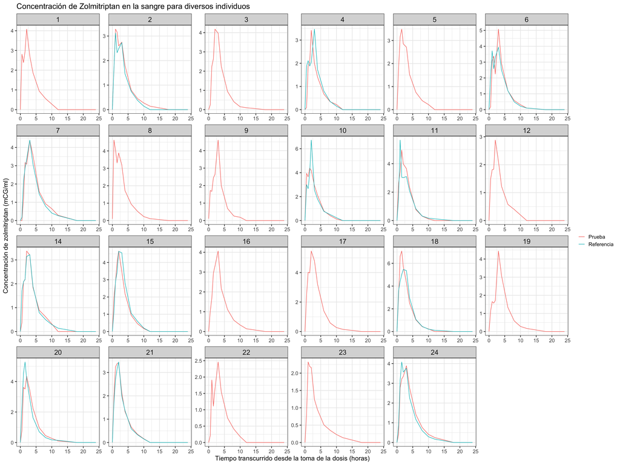

```r
# Pivoteamos para tener un dataframe que podamos gráficar.
zolmitriptan <- zolmitriptan_raw |> pivot_longer(cols = c(starts_with("HR")), names_prefix = "HR",  names_to = "hora", values_to =  "concentracion") |>
  mutate(hora = as.numeric(hora)/10,
         formulation = if_else(formulation=="T", "Prueba", "Referencia"))

# Realizamos una gráfica por sujeto, y para cada una de las formulaciones disponibles
ggplot(zolmitriptan, aes(x = hora, y = concentracion, group = formulation, colour = formulation)) +
  geom_line() +
  labs(title="Concentración de Zolmitriptan en la sangre para diversos individuos",
       x="Tiempo transcurrido desde la toma de la dosis (horas)",
       y ="Concentración de zolmitriptan (mCG/ml)",
       colour ="") +
  theme(panel.spacing = unit(0.1, "lines")) +
  theme_bw(base_size = 15) +
  theme(strip.text = element_text(size = 16)) +
  facet_wrap(~subj, ncol = 6, scales="free")
```

Para comprobar bioequivalencia la FDA solicita que el medicamento de prueba tenga un comportamiento similar al del medicamento de referencia. Para ello se compara la máxima concentración de medicamento (CMAX), el tiempo que tarda el individuo en alcanzar las concentración máxima en sangre (TMAX), y el área bajo la curva de concentración contra tiempofci (AUC, que acabas de graficar). En particular para que la FDA concluya bioequivalencia se requiere que para cada medición (CMAX, TMAX y AUC) un intervalo de 90% de confianza para el cociente $\mu_T/\mu_R$ de la media del tratamiento de prueba $\mu_T$ y la media de la referencia $\mu_R$ esté contenido en el intervalo $(80\%, 125\%)$. En este ejercicio usarás bootstrap para calcular un intervalo de confianza para el cociente de las medias de AUC.

2. Calcula el AUC para cada individuo en cada tratamiento disponible, usa la fórmula de área trapezoidal:
   $$AUC =
   \sum_{\tau=1}^k(c_\tau + c_{\tau−1}) × (t_\tau − t_{\tau-1}) /
   2$$
   donde $c$ es la concentración y $t$ son las horas. Tip: Si usas las funciones de dplyr puede resultar útil usar `lag()`. Presenta una tabla con tus resultados.

Presentamos una tabla generada con gt.

```r
# Creamos una tabla llamada auc que contiene el área bajo la curva para cada individuo y cada formulación disponible
auc <- zolmitriptan |>
  select(subj, formulation, hora, concentracion) |>
  group_by(subj, formulation) |>
  mutate(hora_base = hora - lag(hora),
         concentracion_altura = (concentracion+lag(concentracion))/2,
         base_altura = hora_base*concentracion_altura) |>
  summarize(auc= sum(base_altura, na.rm=TRUE))
# Trabajamos con una tabla auxiliar para no modificar la información original
aux <- auc |>
  pivot_wider(names_from = "formulation", values_from = "auc") |> # Creamos dos columnas  para el AUC de la formulación de prueba y de referencia
  arrange(subj) |> # Ordenamos por sujeto
  mutate(Sujeto = as.character(subj), # Para asegurarnos que sale bien el resultado en gt
         Prueba = as.character(round(Prueba,1)),
         Prueba = replace_na(Prueba, "N/A"),
         Referencia = as.character(round(Referencia,1)),
         Referencia = replace_na(Referencia, "N/A")
         ) |>
  ungroup() # Para que no duplique las observaciones en gt.

# Creamos una tabla con los títulos adecuados.
aux |>
  select(Sujeto, Prueba, Referencia) |>
  gt() |>
  tab_header(title = "Área bajo la curva para las pruebas de bioequivalencia de una nueva formulación de Zolmitriptan") |>
  cols_label(Sujeto = "Sujeto",
             Prueba = "Formulación de Prueba",
              Referencia = "Formulación de Referencia") |>
  tab_style(style = cell_borders(sides = "all",
                                 color = "gray",
                                 weight = px(1)),
            locations = cells_body()) |>
  cols_align(align = "center",
             columns = everything()) |>
  cols_width(everything() ~ px(150)) |>
  tab_options(table.width = pct(100),
              table.font.size = px(14))
```

Área bajo la curva para las pruebas de bioequivalencia de una nueva formulación de Zolmitriptan

| Sujeto | Formulación de Prueba | Formulación de Referencia |
| --- | --- | --- |
| 1 | 16.2 | N/A |
| 2 | 15 | 12.9 |
| 3 | 16.4 | N/A |
| 4 | 11.1 | 13.1 |
| 5 | 14.1 | N/A |
| 6 | 19 | 18.5 |
| 7 | 21.7 | 20.5 |
| 8 | 18.6 | N/A |
| 9 | 14.8 | N/A |
| 10 | 17.9 | 18.1 |
| 11 | 18 | 16.8 |
| 12 | 11 | N/A |
| 14 | 14.5 | 15.1 |
| 15 | 17.8 | 19.7 |
| 16 | 17.2 | N/A |
| 17 | 24 | N/A |
| 18 | 24.1 | 24.3 |
| 19 | 17.6 | N/A |
| 20 | 17.8 | 17.5 |
| 21 | 13.3 | 12.6 |
| 22 | 10.3 | N/A |
| 23 | 9.7 | N/A |
| 24 | 19.9 | 18.7 |

Para los siguientes incisos usa los datos zolmitriptan.csv, para el $i$-ésimo individuo `subj` tienes mediciones de AUC bajo tratamiento y referencia, denotemos a este par $x_i=(auc_{Ti}, auc_{Ri})$, suponiendo que las $x_i$ se obuvieron de manera aleatoria de una distribución bivariada $P$, entonces la cantidad poblacional de interés es el parámetro $\theta = \mu_T/\mu_R$.

3. Calcula el estimador *plug-in* de $\theta$.

En la pantalla imprimimos los estimadores de razón de AUC, TMAX y CMAX.

```r
zol2 <- read_csv("./datos/zolmitriptan.csv", show_col_types = FALSE)

theta <- zol2 |>
  summarize(mu_auc = sum(AUC)/n(),
            mu_cmax = sum(CMAX)/n(),
            mu_tmax = sum(TMAX)/n(),
            .by = Formulation) |>
  pivot_wider(names_from = "Formulation", values_from = c("mu_auc", "mu_cmax", "mu_tmax")) |>
  mutate(theta_auc = mu_auc_T/mu_auc_R,
         theta_cmax = mu_cmax_T/mu_cmax_R,
         theta_tmax = mu_tmax_T/mu_tmax_R)

sprintf("Estimador plug-in de AUC (Área bajo la curva): %1.3f", theta$theta_auc)
```

```
## [1] "Estimador plug-in de AUC (Área bajo la curva): 0.992"
```

```r
sprintf("Estimador plug-in de CMAX (Concentración máxima): %1.3f", theta$theta_cmax)
```

```
## [1] "Estimador plug-in de CMAX (Concentración máxima): 0.971"
```

```r
sprintf("Estimador plug-in de TMAX (Tiempo en que se alcanzó la máxima concentración): %1.3f", theta$theta_tmax)
```

```
## [1] "Estimador plug-in de TMAX (Tiempo en que se alcanzó la máxima concentración): 1.033"
```

4. Usa bootstrap para generar un intervalo del 90% de confianza para $\theta$, ¿la nueva tableta cumple el criterio de bioequivalencia de la FDA?

La nueva tableta cumple con el criterio de bioequivalencia de la FDA debido a que los intervalos del 90% de confianza bootstrap de los estimadores de razón de AUC, TMAX y CMAX se encuentran dentro del intervalo (80%, 125%) requerido usando tanto el método de percentiles, como el método normal. A continuación presentamos los intervalos de confianza bootstrap de los estimadores de razón utilizando tanto el método de percentiles como el método normal.

```r
# Para reproducibilidad
set.seed(123)
# Realizamos las replicaciones bootsrap
dist_boot <- map_df(1:5000,
                    ~slice_sample(zol2, prop = 1, replace = TRUE, by = Formulation) |>
                      summarize(mu_auc = sum(AUC)/n(),
                                mu_cmax = sum(CMAX)/n(),
                                mu_tmax = sum(TMAX)/n(),
                                .by = Formulation) |>
                      pivot_wider(names_from = "Formulation", values_from = c("mu_auc", "mu_cmax", "mu_tmax")) |>
                      mutate(theta_auc = mu_auc_T/mu_auc_R,
                             theta_cmax = mu_cmax_T/mu_cmax_R,
                             theta_tmax = mu_tmax_T/mu_tmax_R) |>
                      select(theta_auc, theta_cmax, theta_tmax) |>
                      mutate(iter=.x)
                    )

# AUC
print("----AUC")
```

```
## [1] "----AUC"
```

```r
sprintf("Intervalo del 90%% de confianza del estimador de rázon de AUC usando el método de percentiles: (%1.5f , %1.5f)",
        unname(quantile(dist_boot$theta_auc, probs = c(0.05))),
        unname(quantile(dist_boot$theta_auc, probs = c(0.95)))
        )
```

```
## [1] "Intervalo del 90% de confianza del estimador de rázon de AUC usando el método de percentiles: (0.88958 , 1.10242)"
```

```r
# La dist. normal acumula el 90% de la distribución en aproximadamente 1.645 la desviación estándar alrededor de la media
sprintf("Intervalo del 90%% de confianza del estimador de rázon de AUC el método normal: (%1.5f , %1.5f)",
        theta$theta_auc - 1.645*sd(dist_boot$theta_auc),
        theta$theta_auc + 1.645*sd(dist_boot$theta_auc)
        )
```

```
## [1] "Intervalo del 90% de confianza del estimador de rázon de AUC el método normal: (0.88509 , 1.09808)"
```

```r
print("El intervalo de confianza bootstrap del estimador de razón de AUC se encuentra dentro de los requerimientos de la FDA")
```

```
## [1] "El intervalo de confianza bootstrap del estimador de razón de AUC se encuentra dentro de los requerimientos de la FDA"
```

```r
print("----CMAX")
```

```
## [1] "----CMAX"
```

```r
sprintf("Intervalo del 90%% de confianza del estimador de rázon de CMAX usando el método de percentiles: (%1.5f , %1.5f)",
        unname(quantile(dist_boot$theta_cmax, probs = c(0.05))),
        unname(quantile(dist_boot$theta_cmax, probs = c(0.95)))
        )
```

```
## [1] "Intervalo del 90% de confianza del estimador de rázon de CMAX usando el método de percentiles: (0.85395 , 1.09627)"
```

```r
# La dist. normal acumula el 90% de la distribución en aproximadamente 1.645 la desviación estándar alrededor de la media
sprintf("Intervalo del 90%% de confianza del estimador de rázon de CMAX el método normal: (%1.5f , %1.5f)",
        theta$theta_cmax - 1.645*sd(dist_boot$theta_cmax),
        theta$theta_cmax + 1.645*sd(dist_boot$theta_cmax)
        )
```

```
## [1] "Intervalo del 90% de confianza del estimador de rázon de CMAX el método normal: (0.84910 , 1.09251)"
```

```r
print("El intervalo de confianza bootstrap del estimador de razón de CMAX se encuentra dentro de los requerimientos de la FDA")
```

```
## [1] "El intervalo de confianza bootstrap del estimador de razón de CMAX se encuentra dentro de los requerimientos de la FDA"
```

```r
print("----TMAX")
```

```
## [1] "----TMAX"
```

```r
sprintf("Intervalo del 90%% de confianza del estimador de rázon de TMAX usando el método de percentiles: (%1.5f , %1.5f)",
        unname(quantile(dist_boot$theta_tmax, probs = c(0.05))),
        unname(quantile(dist_boot$theta_tmax, probs = c(0.95)))
        )
```

```
## [1] "Intervalo del 90% de confianza del estimador de rázon de TMAX usando el método de percentiles: (0.86458 , 1.23082)"
```

```r
# La dist. normal acumula el 90% de la distribución en aproximadamente 1.645 la desviación estándar alrededor de la media
sprintf("Intervalo del 90%% de confianza del estimador de rázon de TMAX el método normal: (%1.5f , %1.5f)",
        theta$theta_tmax - 1.645*sd(dist_boot$theta_tmax),
        theta$theta_tmax + 1.645*sd(dist_boot$theta_tmax)
        )
```

```
## [1] "Intervalo del 90% de confianza del estimador de rázon de TMAX el método normal: (0.84699 , 1.21823)"
```

```r
print("El intervalo de confianza bootstrap del estimador de razón de TMAX se encuentra dentro de los requerimientos de la FDA")
```

```
## [1] "El intervalo de confianza bootstrap del estimador de razón de TMAX se encuentra dentro de los requerimientos de la FDA"
```

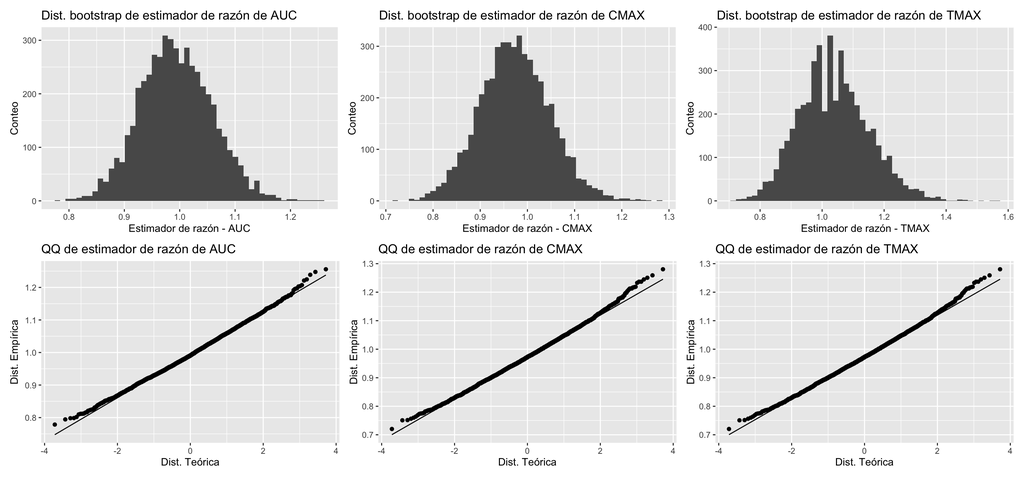

```r
# Realizamos gráficas de la distribución bootstrap y de los qq plots de cada estimador de razón.
dist_boot_auc  <- ggplot(dist_boot, aes(x=theta_auc)) +
  geom_histogram(bins = 50)  + labs(title="Dist. bootstrap de estimador de razón de AUC", x = "Estimador de razón - AUC", y = "Conteo")
dist_boot_cmax <- ggplot(dist_boot, aes(x=theta_cmax)) +
  geom_histogram(bins = 50) + labs(title="Dist. bootstrap de estimador de razón de CMAX", x = "Estimador de razón - CMAX", y = "Conteo")
dist_boot_tmax <- ggplot(dist_boot, aes(x=theta_tmax)) +
  geom_histogram(bins = 50) + labs(title="Dist. bootstrap de estimador de razón de TMAX", x = "Estimador de razón - TMAX", y = "Conteo")

qq_auc <- ggplot(dist_boot, aes(sample=theta_auc))+ stat_qq() + stat_qq_line() +labs(title="QQ de estimador de razón de AUC", y="Dist. Empírica", x="Dist. Teórica")
qq_cmax <- ggplot(dist_boot, aes(sample=theta_cmax))+ stat_qq() + stat_qq_line() +labs(title="QQ de estimador de razón de CMAX", y="Dist. Empírica", x="Dist. Teórica")
qq_tmax <- ggplot(dist_boot, aes(sample=theta_cmax))+ stat_qq() + stat_qq_line() +labs(title="QQ de estimador de razón de TMAX", y="Dist. Empírica", x="Dist. Teórica")

(dist_boot_auc + dist_boot_cmax + dist_boot_tmax) / (qq_auc + qq_cmax +qq_tmax)
```

### 3. Bootstrap encuestas

En este ejercicio utilizarás la Encuesta Nacional sobre Disponibilidad y Uso de Tecnologías de la Información en los Hogares (ENDUTIH) para estimar a nivel nacional:

- la proporción de hogares que tienen acceso a internet.
- la proporción de hogares con teléfono fijo.
- la proporción de hogares con teléfono móvil.
1. Reporta estimaciones puntuales e intervalos de confianza del 95% (utilizando bootstrap de Rao y Wu, puedes usar los paquetes survey o srvyr).

**Respuesta**

```r
set.seed(123)
dic_endutih <- read_csv("./datos/endutih/diccionario_de_datos_tr_endutih_hogares_anual_2023.csv", show_col_types = FALSE)
tr_endutih <- read_csv("./datos/endutih/tr_endutih_hogares_anual_2023.csv", show_col_types = FALSE)
# Transformamos tibble a tbl_svy
endutih_design <- tr_endutih |>
  select(UPM, FAC_HOG, EST_DIS, P4_4, P4_1_6, P5_5, ENT) |> # solo nos quedamos con las columnas que utilizaremos para que las replicaciones se realicen rapidamente
  mutate(con_internet = if_else(P4_4==1,1,0), # Realizamos dummy para calcular de manera más sencilla las proporciones
         con_movil    = if_else(P4_1_6==1,1,0),
         con_fijo     = if_else(P5_5==1,1,0)) |>
  select(UPM, FAC_HOG, EST_DIS, ENT, con_internet, con_movil, con_fijo) |>
  as_survey_design(ids = UPM, weights = FAC_HOG, strata = EST_DIS) # Transformamos a objeto de diseño muestral

# Realizamos las replicaciones bootstrap
endutih_boot <- endutih_design %>%
  as_survey_rep(type = "subbootstrap", replicates = 500)
```

```r
# Calculamos las estimaciones puntuales de las proporciones
metricas <- endutih_boot %>%
  srvyr::summarise(prop_internet = survey_mean(con_internet),
                   prop_movil    = survey_mean(con_movil),
                   prop_fijo    = survey_mean(con_fijo))

# Imprimimos en la pantalla las estimaciones puntuales y los intervalos de confianza
sprintf("Estimador puntual de la proporción de hogares con acceso a internet: %1.5f", metricas$prop_internet)
```

```
## [1] "Estimador puntual de la proporción de hogares con acceso a internet: 0.71654"
```

```r
sprintf("Estimador puntual de la proporción de hogares con teléfono fijo: %1.5f", metricas$prop_fijo)
```

```
## [1] "Estimador puntual de la proporción de hogares con teléfono fijo: 0.37423"
```

```r
sprintf("Estimador puntual de la proporción de hogares con teléfono móvil: %1.5f", metricas$prop_movil)
```

```
## [1] "Estimador puntual de la proporción de hogares con teléfono móvil: 0.95052"
```

```r
sprintf("Intervalo del 95%% de confianza de la proporciòn de hogares con acceso a internet: (%1.5f, %1.5f)",
        metricas$prop_internet-2*metricas$prop_internet_se,
        metricas$prop_internet+2*metricas$prop_internet_se)
```

```
## [1] "Intervalo del 95% de confianza de la proporciòn de hogares con acceso a internet: (0.71005, 0.72303)"
```

```r
sprintf("Intervalo del 95%% de confianza de la proporciòn de hogares con teléfono fijo: (%1.5f, %1.5f)",
        metricas$prop_fijo-2*metricas$prop_fijo_se,
        metricas$prop_fijo+2*metricas$prop_fijo_se)
```

```
## [1] "Intervalo del 95% de confianza de la proporciòn de hogares con teléfono fijo: (0.36808, 0.38039)"
```

```r
sprintf("Intervalo del 95%% de confianza de la proporciòn de hogares con teléfono móvil: (%1.5f, %1.5f)",
        metricas$prop_movil-2*metricas$prop_movil_se,
        metricas$prop_movil+2*metricas$prop_movil_se)
```

```
## [1] "Intervalo del 95% de confianza de la proporciòn de hogares con teléfono móvil: (0.94813, 0.95292)"
```

2. Elige una de las métricas de arriba y calcula intervalos de confianza por estado, grafica los intervalos y discute los resultados.

Utilizaremos la proporción de hogares con acceso a internet. Del cálculo de las proporcines por estado podemos observar que: - Los 5 estados con una menor proporción de hogares con acces a internet son: Chiapas (44.28%), Oaxaca (52.96%), Guerrero (53.86%), Veracruz (58.18%) y Puebla (58.33%). - Los 5 estados con una mayor proporción de hogares con acces a internet son: Ciudad de México (89.47%), Baja California (86.44%), Quintana Roo (83.60%), Jalisco (83.34%) y Aguascalientes (81.43%).

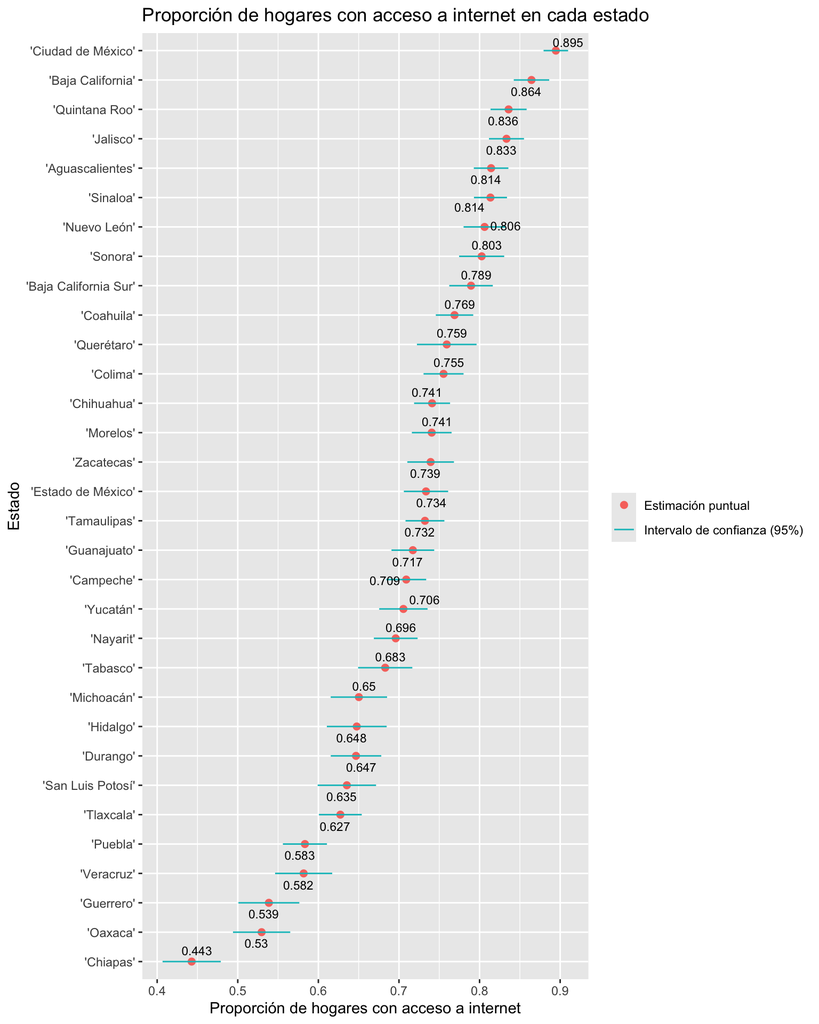

```r
estado_internet <- endutih_boot |>
  group_by(ENT) |>
  srvyr::summarise(prop_internet = survey_mean(con_internet)) |>
  mutate(inf = prop_internet - 2* prop_internet_se,
         sup = prop_internet + 2* prop_internet_se)

# Añadimos un archivo con los nombres de los estados
estados <- read_delim("./datos/estados.txt", show_col_types = FALSE)
estado_internet_2 <- left_join(estado_internet, estados, by="ENT") |>select(nombre, inf, sup, prop_internet) |> arrange(nombre)# Creamos objeto nuevo para no tener problemas con el left_join

# Esta línea nos asegura que en el gráfico los estados se ordenen en orden alfabetico
estado_internet_2$nombre <- fct_reorder(estado_internet_2$nombre, estado_internet_2$prop_internet, .desc = FALSE)

# Realizamos una gráfica por estado de la estimación puntual de la proporción de hogares con acceso a internet y su intervalo de confianza
ggplot(estado_internet_2, aes(x = prop_internet, y = nombre, xmax = sup, xmin = inf)) +
  geom_point(aes(colour = "Estimación puntual"), size = 2) +
  geom_linerange(aes(colour = "Intervalo de confianza (95%)")) +
  geom_hline(yintercept = 0, colour = "gray") +
  geom_text_repel(aes(label = round(prop_internet,3)), size=3) +
  labs(title="Proporción de hogares con acceso a internet en cada estado",
       x="Proporción de hogares con acceso a internet",
       y="Estado",
       colour = "",
       size="")
```